# RNA-seq Differential Expression Analysis of Exercise-Responsive Genes

Vincent Casilio

# Project Overview

This analysis investigates exercise-induced changes in gene expression in human skeletal muscle using RNA-seq data from GEO accession **GSE120862**.

A subset of six RNA-seq samples representing three paired subjects was analyzed. Each subject contributed a baseline and post-exercise sample, allowing differential expression to be evaluated while accounting for inter-individual variation.

The computational workflow consisted of:

**FASTQ → FastQC → HISAT2 → sorted BAM → featureCounts → DESeq2**

Raw sequencing reads were quality checked with FastQC, aligned to the GRCh38 human reference genome using HISAT2, and quantified at the gene level using featureCounts. Differential expression analysis was then performed in R using DESeq2.

The six-sample subset was used because of computational resource limitations during the original analysis.

# Analysis Environment

```r
knitr::opts_chunk$set(
  echo = TRUE,
  message = FALSE,
  warning = FALSE
)

library(DESeq2)
library(ggplot2)
library(AnnotationDbi)
library(org.Hs.eg.db)
```

# Import Gene Count Data

Gene-level read counts generated by **featureCounts** were imported into R.

```r
counts_raw <- read.delim(
  "data/gene_counts_clean.txt",
  comment.char = "#",
  check.names = FALSE
)

dim(counts_raw)
```

```
## [1] 62700    12
```

```r
head(counts_raw)
```

```
##              Geneid                                                    Chr
## 1 ENSG00000290825.1                                         chr1;chr1;chr1
## 2 ENSG00000223972.6                          chr1;chr1;chr1;chr1;chr1;chr1
## 3 ENSG00000227232.5 chr1;chr1;chr1;chr1;chr1;chr1;chr1;chr1;chr1;chr1;chr1
## 4 ENSG00000278267.1                                                   chr1
## 5 ENSG00000243485.5                               chr1;chr1;chr1;chr1;chr1
## 6 ENSG00000284332.1                                                   chr1
##                                                               Start
## 1                                                 11869;12613;13221
## 2                               12010;12179;12613;12975;13221;13453
## 3 14404;15005;15796;16607;16858;17233;17606;17915;18268;24738;29534
## 4                                                             17369
## 5                                     29554;30267;30564;30976;30976
## 6                                                             30366
##                                                                 End
```

[output cut: 20 more lines]

# Sample Metadata

The analysis contains three subjects, each sampled at baseline and after exercise.

A paired experimental design allows each post-exercise sample to be compared while accounting for the corresponding subject.

```r
metadata <- data.frame(
  sample = c(
    "SRR7967702",
    "SRR7967703",
    "SRR7967714",
    "SRR7967715",
    "SRR7967726",
    "SRR7967727"
  ),
  subject = factor(c(
    "subject1",
    "subject1",
    "subject2",
    "subject2",
    "subject3",
    "subject3"
  )),
  time_point = factor(
    c(
      "baseline",
      "post",
      "baseline",
      "post",
      "baseline",
      "post"
    ),
    levels = c("baseline", "post")
  )
)

rownames(metadata) <- metadata$sample

metadata
```

```
##                sample  subject time_point
## SRR7967702 SRR7967702 subject1   baseline
## SRR7967703 SRR7967703 subject1       post
## SRR7967714 SRR7967714 subject2   baseline
## SRR7967715 SRR7967715 subject2       post
## SRR7967726 SRR7967726 subject3   baseline
## SRR7967727 SRR7967727 subject3       post
```

# Prepare Count Matrix

The featureCounts output contains genomic annotation columns in addition to the sample count columns.

Only the gene identifier and RNA-seq sample counts are retained for DESeq2.

```r
sample_columns <- metadata$sample

count_matrix <- counts_raw[, c("Geneid", sample_columns)]

rownames(count_matrix) <- count_matrix$Geneid

count_matrix$Geneid <- NULL

count_matrix <- round(as.matrix(count_matrix))

storage.mode(count_matrix) <- "integer"

dim(count_matrix)
```

```
## [1] 62700     6
```

```r
count_matrix[1:6, ]
```

```
##                   SRR7967702 SRR7967703 SRR7967714 SRR7967715 SRR7967726
## ENSG00000290825.1          0          0          0          0          0
## ENSG00000223972.6          0          0          0          0          0
## ENSG00000227232.5          2         43          0          2         20
## ENSG00000278267.1          0          0          0          0          0
## ENSG00000243485.5          0          0          0          0          0
## ENSG00000284332.1          0          0          0          0          0
##                   SRR7967727
## ENSG00000290825.1          0
## ENSG00000223972.6          0
## ENSG00000227232.5          1
## ENSG00000278267.1          2
## ENSG00000243485.5          0
## ENSG00000284332.1          0
```

Verify that the count matrix and metadata contain samples in the same order.

```r
stopifnot(
  all(colnames(count_matrix) == rownames(metadata))
)

colnames(count_matrix)
```

```
## [1] "SRR7967702" "SRR7967703" "SRR7967714" "SRR7967715" "SRR7967726"
## [6] "SRR7967727"
```

```r
rownames(metadata)
```

```
## [1] "SRR7967702" "SRR7967703" "SRR7967714" "SRR7967715" "SRR7967726"
## [6] "SRR7967727"
```

# DESeq2 Dataset

A DESeq2 dataset was constructed using a paired design:

**~ subject + time_point**

Including `subject` in the model accounts for baseline differences in gene expression between individuals while testing for changes associated with exercise.

```r
dds <- DESeqDataSetFromMatrix(
  countData = count_matrix,
  colData = metadata,
  design = ~ subject + time_point
)

dds
```

```
## class: DESeqDataSet
## dim: 62700 6
## metadata(1): version
## assays(1): counts
## rownames(62700): ENSG00000290825.1 ENSG00000223972.6 ...
##   ENSG00000210195.2 ENSG00000210196.2
## rowData names(0):
## colnames(6): SRR7967702 SRR7967703 ... SRR7967726 SRR7967727
## colData names(3): sample subject time_point
```

# Low-Count Filtering

Genes with very few reads across all samples provide limited information for differential expression analysis.

Genes with fewer than 10 total reads across the six samples were removed before model fitting.

```r
genes_before <- nrow(dds)

keep <- rowSums(counts(dds)) >= 10

dds <- dds[keep, ]

genes_after <- nrow(dds)

cat("Genes before filtering:", genes_before, "\n")
```

```
## Genes before filtering: 62700
```

```r
cat("Genes retained:", genes_after, "\n")
```

```
## Genes retained: 22770
```

```r
cat("Genes removed:", genes_before - genes_after, "\n")
```

```
## Genes removed: 39930
```

# Differential Expression Analysis

DESeq2 models RNA-seq count data using a **negative binomial generalized linear model**.

The model estimates gene-specific expression differences between baseline and post-exercise samples while accounting for subject-level variation.

```r
dds <- DESeq(dds)
```

The post-exercise condition is compared against baseline.

```r
res <- results(
  dds,
  contrast = c("time_point", "post", "baseline"),
  alpha = 0.05
)

summary(res)
```

```
##
## out of 22770 with nonzero total read count
## adjusted p-value < 0.05
## LFC > 0 (up)       : 349, 1.5%
## LFC < 0 (down)     : 131, 0.58%
## outliers [1]       : 0, 0%
## low counts [2]     : 6622, 29%
## (mean count < 12)
## [1] see 'cooksCutoff' argument of ?results
## [2] see 'independentFiltering' argument of ?results
```

# Differential Expression Results

Convert the DESeq2 results object to a data frame for downstream analysis.

```r
res_df <- as.data.frame(res)

res_df$gene_id <- rownames(res_df)

res_df <- res_df[
  order(res_df$padj),
]

head(res_df, 10)
```

```
##                      baseMean log2FoldChange     lfcSE     stat        pvalue
## ENSG00000119508.18 10523.5331       6.578347 0.2385396 27.57759 2.066361e-167
## ENSG00000185022.12  2995.7952       6.181931 0.2577059 23.98831 3.682503e-127
## ENSG00000123358.20 12112.4377       3.543275 0.2423751 14.61897  2.125817e-48
## ENSG00000144136.11  1279.3784       2.377988 0.1872857 12.69711  6.135194e-37
## ENSG00000006210.7    935.4275       2.375398 0.1881707 12.62363  1.564340e-36
## ENSG00000112715.26 11868.2696       2.071723 0.1644176 12.60037  2.101584e-36
## ENSG00000117461.15   874.7822       2.461943 0.1974204 12.47056  1.080636e-35
## ENSG00000148339.13  6227.9177       2.417896 0.2003142 12.07052  1.511790e-33
## ENSG00000158022.7  25743.8763       2.389247 0.1996124 11.96943  5.137746e-33
## ENSG00000158050.5    164.9405       4.201410 0.3642551 11.53425  8.865599e-31
##                             padj            gene_id
## ENSG00000119508.18 3.336760e-163 ENSG00000119508.18
## ENSG00000185022.12 2.973253e-123 ENSG00000185022.12
## ENSG00000123358.20  1.144257e-44 ENSG00000123358.20
## ENSG00000144136.11  2.476778e-33 ENSG00000144136.11
## ENSG00000006210.7   5.052193e-33  ENSG00000006210.7
## ENSG00000112715.26  5.656063e-33 ENSG00000112715.26
## ENSG00000117461.15  2.492872e-32 ENSG00000117461.15
## ENSG00000148339.13  3.051549e-30 ENSG00000148339.13
## ENSG00000158022.7   9.218259e-30  ENSG00000158022.7
## ENSG00000158050.5   1.431617e-27  ENSG00000158050.5
```

The primary statistics reported by DESeq2 include:

- **baseMean** — mean normalized expression across samples
- **log2FoldChange** — magnitude and direction of expression change
- **pvalue** — unadjusted statistical significance
- **padj** — p-value adjusted for multiple testing

Positive log2 fold changes indicate higher expression post-exercise, while negative values indicate lower expression post-exercise.

# Significant Differentially Expressed Genes

Genes with an adjusted p-value below 0.05 were considered statistically significant.

```r
sig <- subset(
  res_df,
  !is.na(padj) & padj < 0.05
)

cat(
  "Significant genes (adjusted p-value < 0.05):",
  nrow(sig),
  "\n"
)
```

```
## Significant genes (adjusted p-value < 0.05): 480
```

# Gene Annotation

Ensembl gene identifiers were mapped to human gene symbols and gene names to support biological interpretation of the differential expression results.

```r
# Remove version numbers from Ensembl IDs
res_df$ensembl_id <- sub("\\..*$", "", res_df$gene_id)

# Map Ensembl IDs to human gene symbols
res_df$symbol <- mapIds(
  org.Hs.eg.db,
  keys = res_df$ensembl_id,
  column = "SYMBOL",
  keytype = "ENSEMBL",
  multiVals = "first"
)

# Map Ensembl IDs to full gene names
res_df$gene_name <- mapIds(
  org.Hs.eg.db,
  keys = res_df$ensembl_id,
  column = "GENENAME",
  keytype = "ENSEMBL",
  multiVals = "first"
)

# Recreate significant gene table with annotations included
sig <- subset(
  res_df,
  !is.na(padj) & padj < 0.05
)
```

# Top Upregulated Genes

Significant genes were ranked by log2 fold change to identify genes showing the largest increases in expression following exercise.

```r
top_up <- sig[
  order(-sig$log2FoldChange),
]

top_up_annotated <- top_up[
  !is.na(top_up$symbol) &
  !is.na(top_up$gene_name) &
  !grepl("^LOC", top_up$symbol),
]

head(
  top_up_annotated[, c(
    "symbol",
    "gene_name",
    "gene_id",
    "baseMean",
    "log2FoldChange",
    "pvalue",
    "padj"
  )],
  10
)
```

```
##                      symbol                                      gene_name
## ENSG00000279685.2  MAPT-IT1                     MAPT intronic transcript 1
## ENSG00000119508.18    NR4A3  nuclear receptor subfamily 4 group A member 3
## ENSG00000185022.12     MAFF                MAF bZIP transcription factor F
## ENSG00000008118.10   CAMK1G calcium/calmodulin dependent protein kinase IG
## ENSG00000105523.4    SACK1E            scaffolding CK1 anchoring protein E
## ENSG00000175592.9     FOSL1  FOS like 1, AP-1 transcription factor subunit
## ENSG00000158050.5     DUSP2                 dual specificity phosphatase 2
## ENSG00000271086.7  STX17-DT                     STX17 divergent transcript
## ENSG00000179388.9      EGR3                        early growth response 3
## ENSG00000123358.20    NR4A1  nuclear receptor subfamily 4 group A member 1
##                               gene_id    baseMean log2FoldChange        pvalue
## ENSG00000279685.2   ENSG00000279685.2    19.78239       7.465833  2.775819e-08
## ENSG00000119508.18 ENSG00000119508.18 10523.53310       6.578347 2.066361e-167
## ENSG00000185022.12 ENSG00000185022.12  2995.79518       6.181931 3.682503e-127
## ENSG00000008118.10 ENSG00000008118.10    17.44434       5.180259  1.385820e-05
## ENSG00000105523.4   ENSG00000105523.4    45.02770       4.997017  7.022208e-14
## ENSG00000175592.9   ENSG00000175592.9    34.84858       4.448040  1.053242e-09
## ENSG00000158050.5   ENSG00000158050.5   164.94047       4.201410  8.865599e-31
## ENSG00000271086.7   ENSG00000271086.7    39.01554       3.736649  5.812646e-11
## ENSG00000179388.9   ENSG00000179388.9   183.50880       3.551972  3.650809e-04
## ENSG00000123358.20 ENSG00000123358.20 12112.43769       3.543275  2.125817e-48
##                             padj
## ENSG00000279685.2   3.674092e-06
## ENSG00000119508.18 3.336760e-163
## ENSG00000185022.12 2.973253e-123
## ENSG00000008118.10  1.021837e-03
## ENSG00000105523.4   2.223424e-11
## ENSG00000175592.9   1.868984e-07
## ENSG00000158050.5   1.431617e-27
## ENSG00000271086.7   1.203367e-08
## ENSG00000179388.9   1.703852e-02
## ENSG00000123358.20  1.144257e-44
```

# Top Downregulated Genes

Significant genes were ranked by log2 fold change to identify genes showing the largest decreases in expression following exercise.

```r
top_down <- sig[
  order(sig$log2FoldChange),
]

top_down_annotated <- top_down[
  !is.na(top_down$symbol) &
  !is.na(top_down$gene_name) &
  !grepl("^LOC", top_down$symbol),
]

head(
  top_down_annotated[, c(
    "symbol",
    "gene_name",
    "gene_id",
    "baseMean",
    "log2FoldChange",
    "pvalue",
    "padj"
  )],
  10
)
```

```
##                    symbol                                gene_name
## ENSG00000276409.5   CCL14            C-C motif chemokine ligand 14
## ENSG00000124253.11   PCK1      phosphoenolpyruvate carboxykinase 1
## ENSG00000145934.17  TENM2         teneurin transmembrane protein 2
## ENSG00000172137.19  CALB2                              calbindin 2
## ENSG00000174697.5     LEP                                   leptin
## ENSG00000056998.21   GYG2                             glycogenin 2
## ENSG00000196932.12 TMEM26                 transmembrane protein 26
## ENSG00000187288.12  CIDEC cell death inducing DFFA like effector c
## ENSG00000166819.12  PLIN1                              perilipin 1
## ENSG00000099194.6     SCD                  stearoyl-CoA desaturase
##                               gene_id  baseMean log2FoldChange       pvalue
## ENSG00000276409.5   ENSG00000276409.5  11.94334      -3.391545 7.957519e-04
## ENSG00000124253.11 ENSG00000124253.11  23.91457      -3.046792 4.029522e-05
## ENSG00000145934.17 ENSG00000145934.17  29.95860      -3.034479 3.411554e-05
## ENSG00000172137.19 ENSG00000172137.19  25.84987      -2.646295 5.421049e-04
## ENSG00000174697.5   ENSG00000174697.5  19.06578      -2.544328 1.026428e-03
## ENSG00000056998.21 ENSG00000056998.21  24.11576      -2.335118 2.219793e-04
## ENSG00000196932.12 ENSG00000196932.12  22.71326      -2.276231 3.332837e-04
## ENSG00000187288.12 ENSG00000187288.12  84.81755      -1.917992 9.146002e-08
## ENSG00000166819.12 ENSG00000166819.12 322.12940      -1.826569 1.960934e-14
## ENSG00000099194.6   ENSG00000099194.6 680.58997      -1.824816 2.594135e-18
##                            padj
## ENSG00000276409.5  3.228137e-02
## ENSG00000124253.11 2.595413e-03
## ENSG00000145934.17 2.248562e-03
## ENSG00000172137.19 2.365922e-02
## ENSG00000174697.5  3.819068e-02
## ENSG00000056998.21 1.089520e-02
## ENSG00000196932.12 1.564496e-02
## ENSG00000187288.12 1.102161e-05
## ENSG00000166819.12 7.036701e-12
## ENSG00000099194.6  1.444486e-15
```

# Volcano Plot

A volcano plot was generated to visualize both the magnitude of gene-expression change and statistical significance.

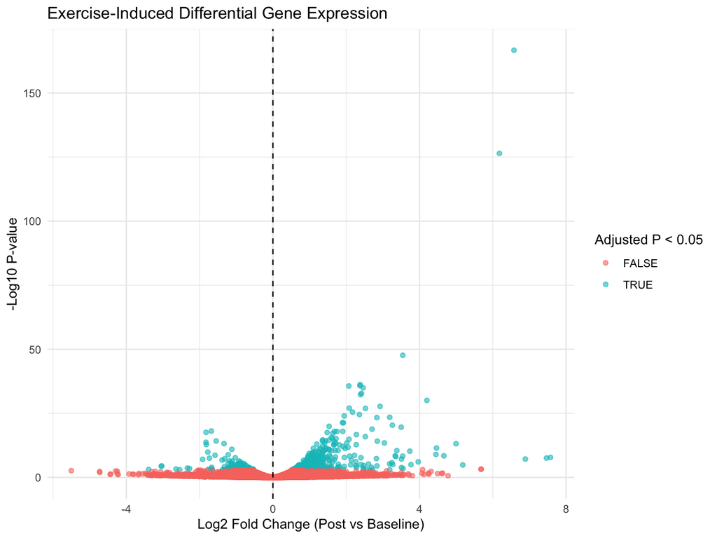

```r
volcano_df <- res_df[
  !is.na(res_df$pvalue) &
  !is.na(res_df$log2FoldChange),
]

volcano_df$significant <- (
  !is.na(volcano_df$padj) &
  volcano_df$padj < 0.05
)

volcano_plot <- ggplot(
  volcano_df,
  aes(
    x = log2FoldChange,
    y = -log10(pvalue),
    color = significant
  )
) +
  geom_point(
    alpha = 0.6,
    size = 1.5
  ) +
  geom_vline(
    xintercept = 0,
    linetype = "dashed"
  ) +
  labs(
    title = "Exercise-Induced Differential Gene Expression",
    x = "Log2 Fold Change (Post vs Baseline)",
    y = "-Log10 P-value",
    color = "Adjusted P < 0.05"
  ) +
  theme_minimal()

# Display plot
volcano_plot
```

```r
# Export high-resolution PNG
ggsave(
  "results/volcano_plot.png",
  plot = volcano_plot,
  width = 8,
  height = 6,
  dpi = 300
)
```

# Principal Component Analysis

Principal Component Analysis (PCA) was performed on variance-stabilized count data to visualize major patterns of gene-expression variation among samples.

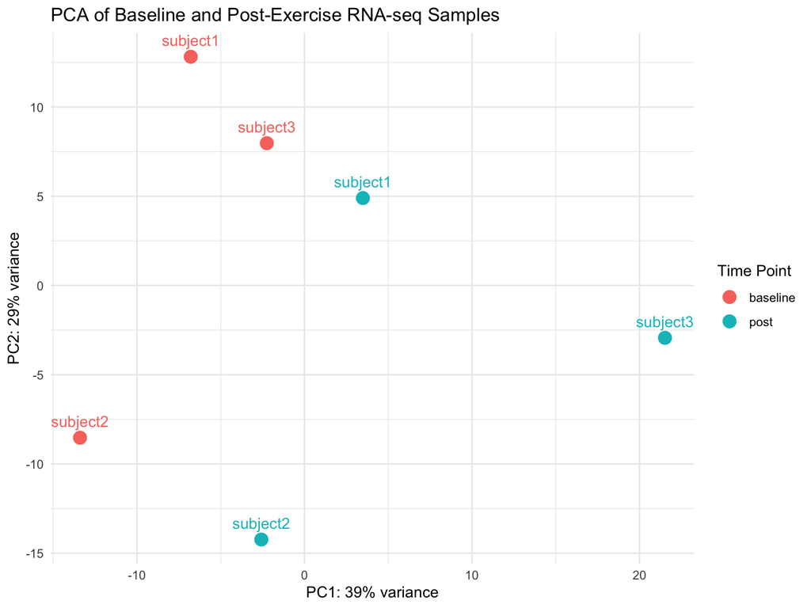

```r
vsd <- vst(
  dds,
  blind = FALSE
)

pca_data <- plotPCA(
  vsd,
  intgroup = c("time_point", "subject"),
  returnData = TRUE
)

percent_var <- round(
  100 * attr(pca_data, "percentVar")
)

pca_plot <- ggplot(
  pca_data,
  aes(
    x = PC1,
    y = PC2,
    color = time_point,
    label = subject
  )
) +
  geom_point(size = 4) +
  geom_text(
    vjust = -1,
    show.legend = FALSE
  ) +
  xlab(
    paste0(
      "PC1: ",
      percent_var[1],
      "% variance"
    )
  ) +
  ylab(
    paste0(
      "PC2: ",
      percent_var[2],
      "% variance"
    )
  ) +
  labs(
    title = "PCA of Baseline and Post-Exercise RNA-seq Samples",
    color = "Time Point"
  ) +
  theme_minimal()

# Display plot
pca_plot
```

```r
# Export high-resolution PNG
ggsave(
  "results/pca_plot.png",
  plot = pca_plot,
  width = 8,
  height = 6,
  dpi = 300
)
```

# Export Results

Differential expression results can be exported for downstream analysis or inclusion in the GitHub repository.

```r
write.csv(
  res_df,
  "results/differential_expression_results.csv",
  row.names = FALSE
)

write.csv(
  sig,
  "results/significant_genes.csv",
  row.names = FALSE
)

write.csv(
  head(top_up_annotated, 10),
  "results/top_upregulated_genes.csv",
  row.names = FALSE
)

write.csv(
  head(top_down_annotated, 10),
  "results/top_downregulated_genes.csv",
  row.names = FALSE
)
```